# General Mills Cereal Sales Analysis

**Closer look at General Mills brands**

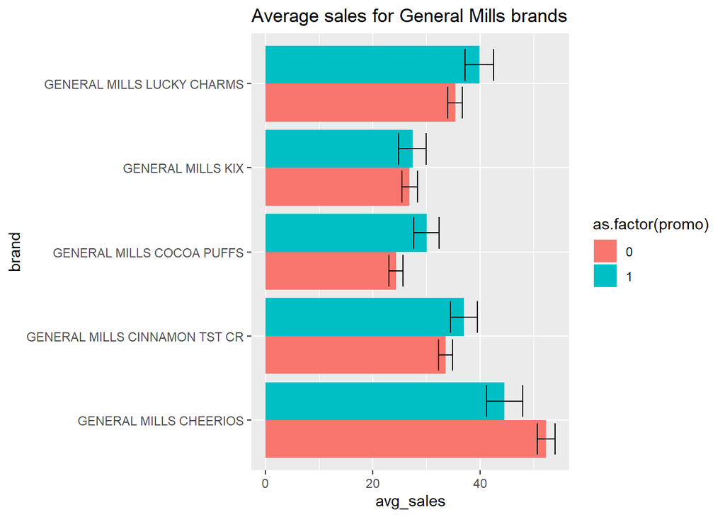

```r
# Bar plots from above for General Mills Brands only
# Average sales
full_df %>%
  filter(company == "General Mills") %>%
  mutate(total_volume = units * volume) %>%
  group_by(company, brand, promo) %>%
  summarize(avg_vol = mean(total_volume), avg_sales = mean(total_sales),
            n = n(), sd_vol = sd(total_volume), sd_sales = sd(total_sales),
            ci_vol = z * sd_vol/sqrt(n), ci_sales = z * sd_sales/sqrt(n)) %>%
  ggplot(mapping = aes(x = brand, y = avg_sales, fill = as.factor(promo))) +
  geom_bar(stat = 'identity', position = 'dodge') +
  coord_flip() +
  labs(title = "Average sales for General Mills brands") +
  geom_errorbar(aes(ymin = avg_sales - ci_sales, ymax = avg_sales + ci_sales),
                width = 0.75, position = position_dodge(0.9))
```

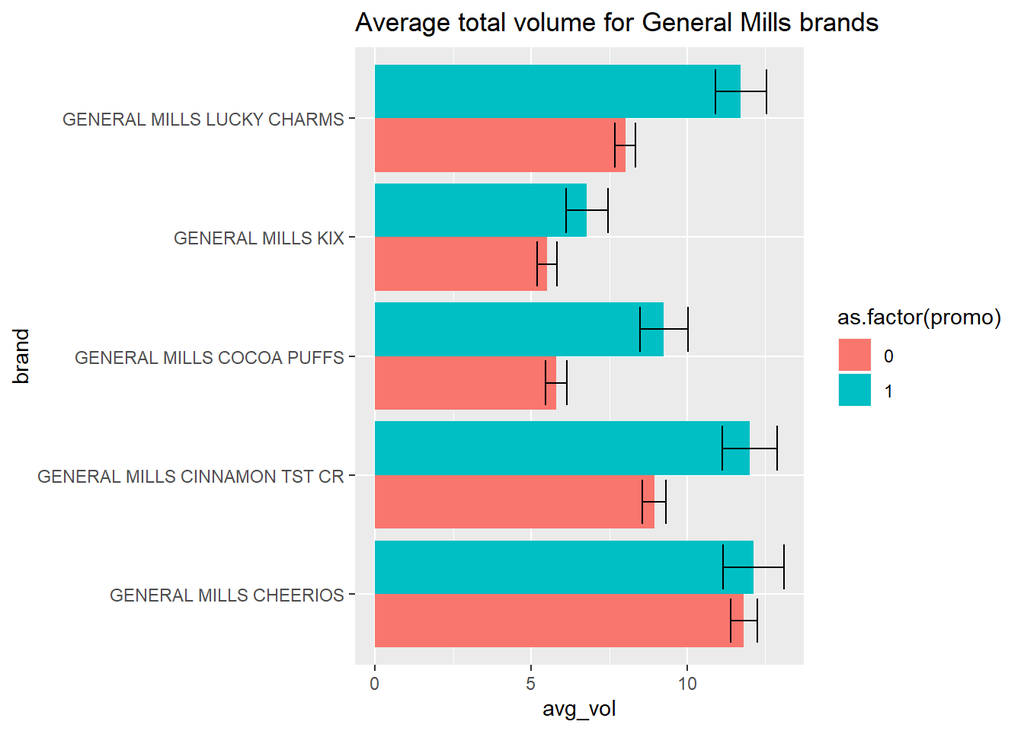

```r
# Average total volume
full_df %>%
  filter(company == "General Mills") %>%
  mutate(total_volume = units * volume) %>%
  group_by(company, brand, promo) %>%
  summarize(avg_vol = mean(total_volume), avg_sales = mean(total_sales),
            n = n(), sd_vol = sd(total_volume), sd_sales = sd(total_sales),
            ci_vol = z * sd_vol/sqrt(n), ci_sales = z * sd_sales/sqrt(n)) %>%
  ggplot(mapping = aes(x = brand, y = avg_vol, fill = as.factor(promo))) +
  geom_bar(stat = 'identity', position = 'dodge') +
  coord_flip() +
  labs(title = "Average total volume for General Mills brands") +
  geom_errorbar(aes(ymin = avg_vol - ci_vol, ymax = avg_vol + ci_vol),
                width = 0.75, position = position_dodge(0.9))
```

- General Mills:
  - Cheerios avg sales are lower with promos, while every other brand increases or stays the same
  - Cheerios avg vol is about the same with and w/out promos while every other brand increases significantly

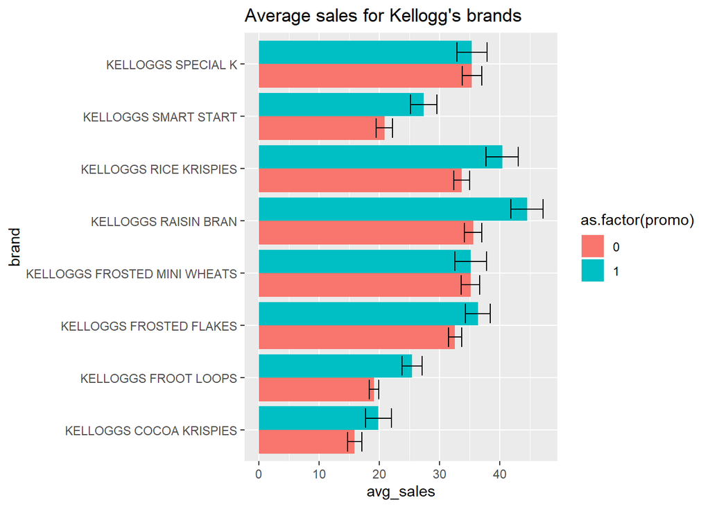

```r
# Bar plots from above for General Mills Brands only
# Average sales
full_df %>%
  filter(company == "Kellogg") %>%
  mutate(total_volume = units * volume) %>%
  group_by(company, brand, promo) %>%
  summarize(avg_vol = mean(total_volume), avg_sales = mean(total_sales),
            n = n(), sd_vol = sd(total_volume), sd_sales = sd(total_sales),
            ci_vol = z * sd_vol/sqrt(n), ci_sales = z * sd_sales/sqrt(n)) %>%
  ggplot(mapping = aes(x = brand, y = avg_sales, fill = as.factor(promo))) +
  geom_bar(stat = 'identity', position = 'dodge') +
  coord_flip() +
  labs(title = "Average sales for Kellogg's brands") +
  geom_errorbar(aes(ymin = avg_sales - ci_sales, ymax = avg_sales + ci_sales),
                width = 0.75, position = position_dodge(0.9))
```

## 7.1 Statistical tests

## 7.2 Test of promo impact to overall General Mills sales

- Ho: GM avg sales w/out promo - GM avg sales w/promo = 0
- Ha: GM avg sales w/out promo - GM avg sales w/promo != 0

Alpha = 0.025

```r
# Set df to t for easier subsetting in t tests
t <- full_df

# Test for differences between promo and non-promo sales for General Mills
t.test(t$total_sales[t$company == "General Mills" & t$promo == 0],
       t$total_sales[t$company == "General Mills" & t$promo == 1],
       conf.level = 0.95)
```

```
##
##  Welch Two Sample t-test
##
## data:  t$total_sales[t$company == "General Mills" & t$promo == 0] and t$total_sales[t$company == "General Mills" & t$promo == 1]
## t = -0.7662, df = 2115.6, p-value = 0.4436
## alternative hypothesis: true difference in means is not equal to 0
## 95 percent confidence interval:
##  -1.9985901  0.8756323
## sample estimates:
## mean of x mean of y
##  35.60590  36.16737
```

- We do not reject the null hypothesis
- There is no statistically significant difference between promo and non-promo sales for General Mills

**Conclusion:** There is no statistical evidence to support that promos make a difference to sales for General Mills overall. However, I will test for differences within each brand.

## 7.3 Tests within General Mills brands for differences in sales for promo v no promo

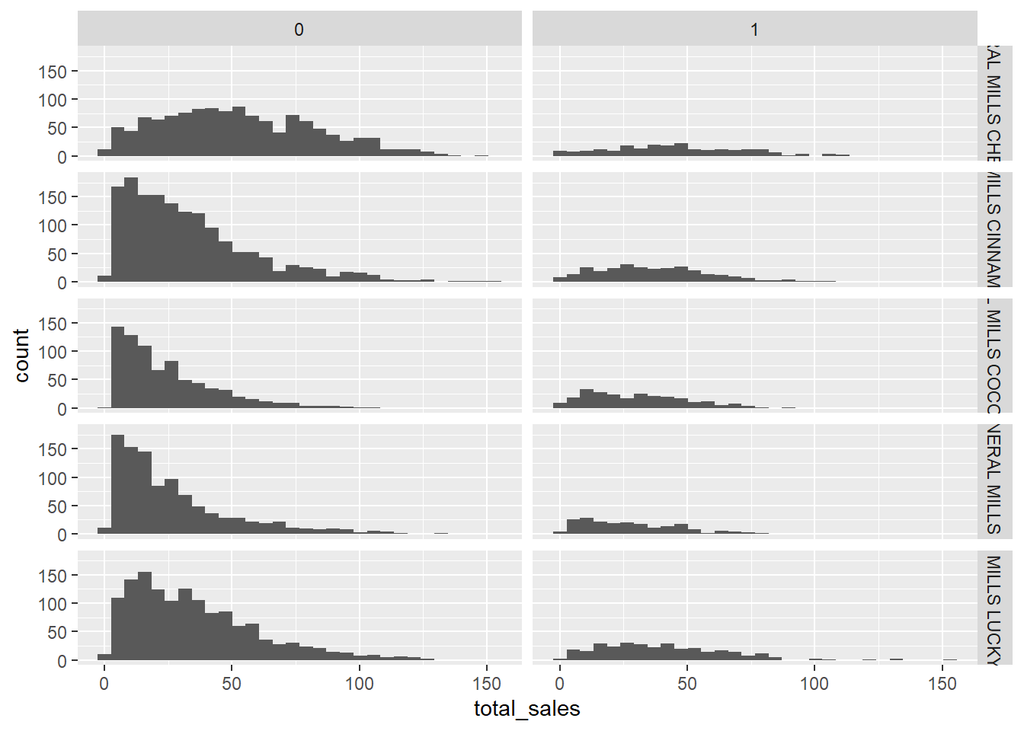

```r
# Check distributions of GM brands
full_df %>%
  filter(company == "General Mills") %>%
  group_by(brand) %>%
  ggplot(mapping = aes(x = total_sales)) +
  geom_histogram() +
  facet_grid(brand~promo)
```

- Without promotions, distributions look right-skewed; but will use test of means for practical purposes

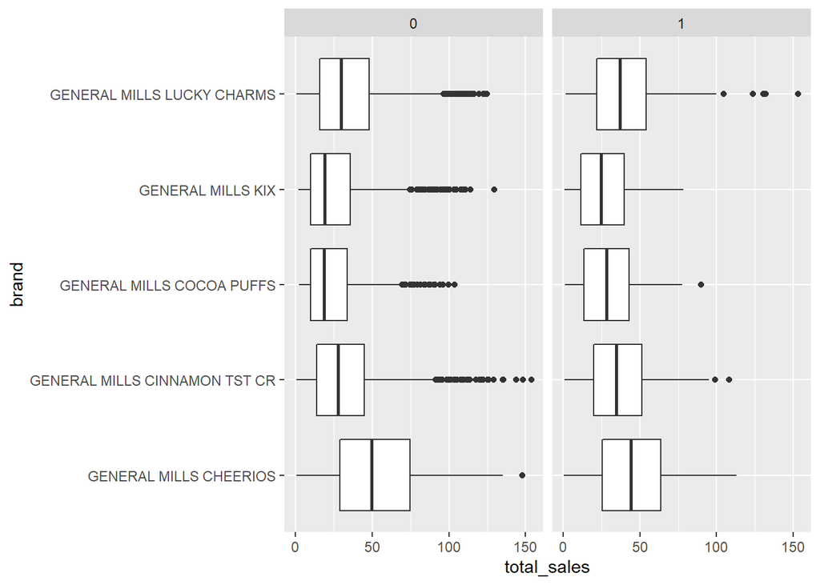

```r
# Check boxplots
full_df %>%
  filter(company == "General Mills") %>%
  group_by(brand) %>%
  ggplot(mapping = aes(y = total_sales, x = brand)) +
  geom_boxplot() +
  coord_flip() +
  facet_grid(.~promo)
```

- Can see the medians shift slightly for most brands when there are promos, with major exception being Cheerios

## 7.4 General Mills brands, promo v no promo

Hypothesis test set-up for all GM brands:

- Ho: Brand avg sales w/ promo - Brand avg sales w/out promo = 0
- Ha: Brand avg sales w/ promo - Brand avg sales w/out promo != 0

Alpha = 0.025

```r
# Test for Lucky Charms
(t1 <- t.test(t$total_sales[t$promo == 1 & t$brand == "GENERAL MILLS LUCKY CHARMS"],
             t$total_sales[t$promo == 0 & t$brand == "GENERAL MILLS LUCKY CHARMS"],
             conf.level = 0.95))
```

```
##
##  Welch Two Sample t-test
##
## data:  t$total_sales[t$promo == 1 & t$brand == "GENERAL MILLS LUCKY CHARMS"] and t$total_sales[t$promo == 0 & t$brand == "GENERAL MILLS LUCKY CHARMS"]
## t = 2.9748, df = 476.11, p-value = 0.003081
## alternative hypothesis: true difference in means is not equal to 0
## 95 percent confidence interval:
##  1.545826 7.561649
## sample estimates:
## mean of x mean of y
##  39.91911  35.36537
```

- reject the null hypothesis
- there is a statistically significant difference between promo and non promo sales for Lucky Charms
- On avg, promo sales are higher than non-promo sales

```r
# Test for Kix
(t2 <- t.test(t$total_sales[t$promo == 1 & t$brand == "GENERAL MILLS KIX"],
             t$total_sales[t$promo == 0 & t$brand == "GENERAL MILLS KIX"],
             conf.level = 0.95))
```

```
##
##  Welch Two Sample t-test
##
## data:  t$total_sales[t$promo == 1 & t$brand == "GENERAL MILLS KIX"] and t$total_sales[t$promo == 0 & t$brand == "GENERAL MILLS KIX"]
## t = 0.34451, df = 335.06, p-value = 0.7307
## alternative hypothesis: true difference in means is not equal to 0
## 95 percent confidence interval:
##  -2.436775  3.471542
## sample estimates:
## mean of x mean of y
##  27.41553  26.89814
```

- do not reject the null hypothesis
- there is no statistically significant difference between promo and non promo sales for Kix

```r
# Test for Cocoa Puffs
(t3 <- t.test(t$total_sales[t$promo == 1 & t$brand == "GENERAL MILLS COCOA PUFFS"],
             t$total_sales[t$promo == 0 & t$brand == "GENERAL MILLS COCOA PUFFS"],
             conf.level = 0.95))
```

```
##
##  Welch Two Sample t-test
##
## data:  t$total_sales[t$promo == 1 & t$brand == "GENERAL MILLS COCOA PUFFS"] and t$total_sales[t$promo == 0 & t$brand == "GENERAL MILLS COCOA PUFFS"]
## t = 4.0746, df = 422.34, p-value = 0.00005507
## alternative hypothesis: true difference in means is not equal to 0
## 95 percent confidence interval:
##  2.953708 8.459441
## sample estimates:
## mean of x mean of y
##  30.04474  24.33817
```

- reject the null hypothesis
- there is a statistically significant difference in promo and non-promo sales for Cocoa Puffs
- on avg, promo sales are higher than non-promo sales

```r
# Test for Cinnamon Toast
(t4 <- t.test(t$total_sales[t$promo == 1 & t$brand == "GENERAL MILLS CINNAMON TST CR"],
             t$total_sales[t$promo == 0 & t$brand == "GENERAL MILLS CINNAMON TST CR"],
             conf.level = 0.95))
```

```
##
##  Welch Two Sample t-test
##
## data:  t$total_sales[t$promo == 1 & t$brand == "GENERAL MILLS CINNAMON TST CR"] and t$total_sales[t$promo == 0 & t$brand == "GENERAL MILLS CINNAMON TST CR"]
## t = 2.3776, df = 465.66, p-value = 0.01783
## alternative hypothesis: true difference in means is not equal to 0
## 95 percent confidence interval:
##  0.5934813 6.2480936
## sample estimates:
## mean of x mean of y
##  37.02077  33.59999
```

- reject the null hypothesis
- there is a statistically significant difference in promo v non promo sales for Cinnamon Toast Crunch
- on avg. promo sales are higher than non-promo sales

```r
# Test for Cheerios
(t5 <- t.test(t$total_sales[t$promo == 1 & t$brand == "GENERAL MILLS CHEERIOS"],
             t$total_sales[t$promo == 0 & t$brand == "GENERAL MILLS CHEERIOS"],
             conf.level = 0.95))
```

```
##
##  Welch Two Sample t-test
##
## data:  t$total_sales[t$promo == 1 & t$brand == "GENERAL MILLS CHEERIOS"] and t$total_sales[t$promo == 0 & t$brand == "GENERAL MILLS CHEERIOS"]
## t = -4.0241, df = 331.68, p-value = 0.0000709
## alternative hypothesis: true difference in means is not equal to 0
## 95 percent confidence interval:
##  -11.500092  -3.948273
## sample estimates:
## mean of x mean of y
##  44.62216  52.34634
```

- reject the null hypothesis
- there is a statistically significant difference between promo and non-promo sales for Cheerios
- on average, promo sales are lower than non-promo sales

## 7.5 Compare Between General Mills and Kellogg

```r
# GM and KG, toasted flavor with promos
t.test(t$total_sales[t$company == "General Mills" & t$promo == 1],
       t$total_sales[t$company == "Kellogg" & t$promo == 1],
       conf.level = 0.95)
```

```
##
##  Welch Two Sample t-test
##
## data:  t$total_sales[t$company == "General Mills" & t$promo == 1] and t$total_sales[t$company == "Kellogg" & t$promo == 1]
## t = 4.6564, df = 2457.2, p-value = 0.000003389
## alternative hypothesis: true difference in means is not equal to 0
## 95 percent confidence interval:
##  2.088151 5.126334
## sample estimates:
## mean of x mean of y
##  36.16737  32.56013
```

```r
# Difference in mean price between GM and KG when there are promos
t.test(t$price[t$company == "General Mills" & t$promo == 1],
       t$price[t$company == "Kellogg" & t$promo == 1],
       conf.level = 0.95)
```

```
##
##  Welch Two Sample t-test
##
## data:  t$price[t$company == "General Mills" & t$promo == 1] and t$price[t$company == "Kellogg" & t$promo == 1]
## t = -0.56267, df = 2353.4, p-value = 0.5737
## alternative hypothesis: true difference in means is not equal to 0
## 95 percent confidence interval:
##  -0.07277325  0.04032213
## sample estimates:
## mean of x mean of y
##  2.961242  2.977468
```

```r
# Difference in mean price between GM and KG for toasted, when there are promos
t.test(t$price[t$company == "General Mills" & t$promo == 1 & t$flavor == "TOASTED"],
       t$price[t$company == "Kellogg" & t$promo == 1 & t$flavor == "TOASTED"],
       conf.level = 0.95)
```

[output not shown]